# OVERBYTES Module4 JM

Joseph Milosh

2022-10-02

# Introduction

The central theme of this project will be to assess the morphological and allometric differences between ecomorphs within the genus Anolis. The term ecomorph describes a group of species, not sharing a most recent common ancestor, but with a similar ecological niche and behavior within the context of this niche. In order to assess the differences between these ecomorphs, we determined how hind limb length varies with size, further relating to ecological niche in a phylogenetic context.

### Centered image of an *Anolis* lizard (Hirst 2006)

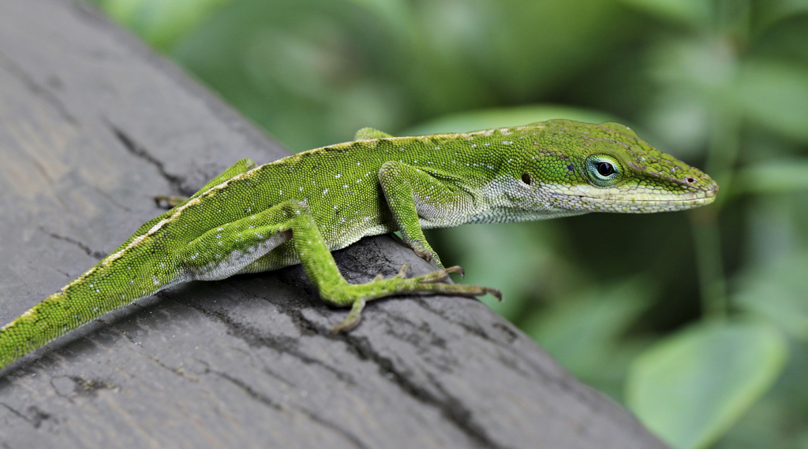

Image of The Anolis Lizard

# Methods

The sets of data on anole lizards were taken from Hagey et al. (2017) (omitting any rows with missing values) and log transformed. Using the anole phylogenetic tree created by data from Poe et al. (2017), four phylogenetic generalized least squares (PGLS) models were created for the hindlimb-SVL relationship, two using the Ornstein-Uhlenbeck (OU) model and two using the Brownian motion model, both with simple regression models that do not include ecomorph and then models that do. The fit of these models were then compared utilizing the Akaike Information Criterion (AIC); these fits are also visualized with various graphs, including the residuals of each model.

### Loading the Data

```r
anole <- read_csv("anole.dat.csv")
anole.eco <- read_csv("anole.eco.csv")
anole.tree <- read.tree("anole.tre")
```

### Cleaning and Merging the Data Sets

```r
anole2 <- anole%>%
left_join(anole.eco)%>%
  filter(!Ecomorph%in%c("U","CH"))%>%
  na.omit()
anole.log <- anole2%>%
  mutate_at(c("SVL", "HTotal","PH","ArbPD"),log)
```

### Creating PGLS Models

```r
### phylogenetic GLS models

#PGLS under BM, no ecomorph
pgls.BM1 <- gls(HTotal ~SVL, correlation = corBrownian(1,phy = anole.tree,form=~Species),data = anole.log, method = "ML")

#PGLS under BM, w ecomorph
pgls.BM2 <- gls(HTotal ~SVL * Ecomorph2, correlation = corBrownian(1,phy = anole.tree,form=~Species),data = anole.log, method = "ML")

#PGLS under OU, no ecomorph
pgls.OU1 <- gls(HTotal ~SVL, correlation = corMartins(0,phy = anole.tree,form=~Species),data = anole.log, method = "ML")

#PGLS under OU, w, ecomorph
pgls.OU2 <- gls(HTotal ~SVL * Ecomorph2, correlation = corMartins(0,phy = anole.tree,form=~Species),data = anole.log, method = "ML")
```

### Determining model fits with AIC

```r
#AIC operations
anole.phylo.aic <- AICc(pgls.BM1,pgls.BM2,pgls.OU1,pgls.OU2)
anole.phylow.aicw <- aicw(anole.phylo.aic$AICc)

print(anole.phylow.aicw)
```

```
##         fit     delta            w
## 1 -63.66118 29.319176 4.225281e-07
## 2 -92.98036  0.000000 9.827289e-01
## 3 -57.31864 35.661714 1.772520e-08
## 4 -84.89770  8.082653 1.727062e-02
```

```r
rownames <- rownames(anole.phylow.aicw)
print(rownames)
```

```
## [1] "1" "2" "3" "4"
```

```r
rownames(anole.phylow.aicw) <- c('PGLS under BM and no ecomorph', 'PGLS under BM with ecomorph', 'PGLS under OU with no ecomorph', 'PGLS under OU with ecomorph')

# Descriptive caption for "AIC" chunk
anole.phylow.aicw %>%
  kable(caption = "This table displays AIC values with kable allows for a comparison of ecomorph
model fits using Akaike Information Criterion.")
```

This table displays AIC values with kable allows for a comparison of ecomorph model fits using Akaike Information Criterion.

|  | fit | delta | w |
| --- | --- | --- | --- |
| PGLS under BM and no ecomorph | -63.66118 | 29.319176 | 0.0000004 |
| PGLS under BM with ecomorph | -92.98036 | 0.000000 | 0.9827289 |
| PGLS under OU with no ecomorph | -57.31864 | 35.661714 | 0.0000000 |
| PGLS under OU with ecomorph | -84.89770 | 8.082653 | 0.0172706 |

### Accounting for Standard Error in Data Through the Creation of Residuals

```r
#add phylo-corrected residuals
anole.log <- anole.log%>%
  mutate(phylo.res=residuals(pgls.BM2))
```

### Plot of Snout-Vent Length Against Mean Total Hind-Limb Length, Color Coded by Ecomorph

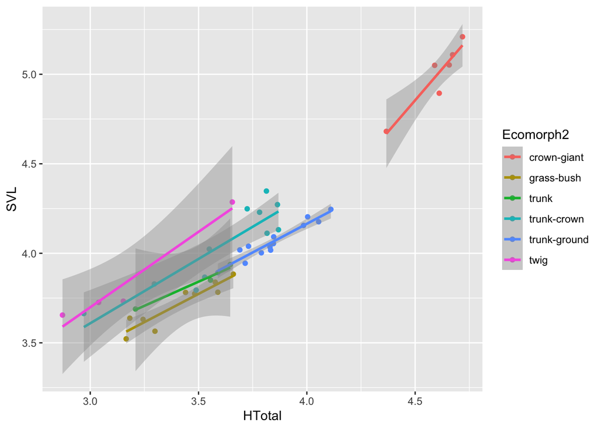

Mean snout-vent length plotted against mean total hind-limb length, color-coded by ecomorph

```r
anole.log%>%
  ggplot(aes(HTotal,SVL,col=Ecomorph2))+geom_point()+geom_smooth(method="lm")
```

### Regression plot of log-transformed HTotal vs SVL

```r
print(anole)
```

```
## # A tibble: 70 × 3
##    Species                   SVL HTotal
##    <chr>                   <dbl>  <dbl>
##  1 Anolis_ahli              57.6   46.8
##  2 Anolis_aliniger          55.9   34.8
##  3 Anolis_allisoni          77.3   45.3
##  4 Anolis_allogus           54.8   44.2
##  5 Anolis_allogus_Eco       NA     NA
##  6 Anolis_alutaceus         35.3   27.1
##  7 Anolis_angusticeps       41.5   20.9
##  8 Anolis_angusticeps_Eco   NA     NA
##  9 Anolis_angusticeps2_Eco  NA     NA
## 10 Anolis_argenteolus       52.6   42.8
## # … with 60 more rows
```

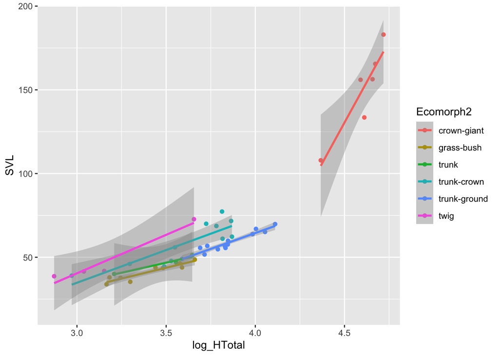

```r
anole.log.plot <- anole%>%
  left_join(anole.eco)%>%
  filter(!Ecomorph%in%c("U","CH"))%>%
  na.omit()%>%
  mutate_at(c("HTotal"),log)%>%
  rename("log_HTotal" = "HTotal")%>%
  ggplot(aes(x=log_HTotal, y=SVL, col=Ecomorph2))+geom_point() + geom_smooth(method = "lm")
print(anole.log.plot)
```